# 2021 Jan-Feb BLi data analysis (curve-fitting approach)

Bin He

3/29/2021

## Goal

Analyze BLI data to check the consistency between batches of experiments and compare the binding affinities between ScPho4 vs CgPho4 DBDs against the consensus motif and the nine 1-bp-off variants.

### 2021-03-29 update

What’s new in this analysis is that Chris Ptak joined the P&CF and helped us prepare two batches of ScPho4 DBD and CgPho4 DBD. The quality of the protein is high and stayed high over the course of over a month at 4C. I was thus able to screen the 10 oligo library for both proteins. Another new piece is the method used for inferring Kd. In all past analyses, I use the Octet data analysis softwrae to extract the Req by averaging the signal over 5 sec close to the end of the association phase. I then fit a one-site specific binding equation to the Req values over the series of protein titration (concentration series) in Prism. In this analysis, I used the built-in curve fitting functions in the Data Analysis software, which fits the kinetic curves (sensorgram for association and dissociation) to extract both the equilibrium dissociation constant $K_d$ as well as the kinetic parameters $k_{on}$ and $k_{off}$.

> to discuss: reason to use (or not to use) kinetic curve fitting vs the equilibrium state fitting

## Data

[output not shown]

## Load data

```r
dat <- read_tsv("../data/BLI/2021-Jan-Feb-Kd-estimates.tsv") %>%
  filter(!is.na(Model)) %>%
  mutate(Half_site = factor(str_sub(Ligand,7,9),
                            levels = c("CAC","AAC","TAC","GAC","CTC","CCC","CGC","CAA","CAT","CAG")))
```

## Compare ScPho4 and CgPho4 DBD binding affinities

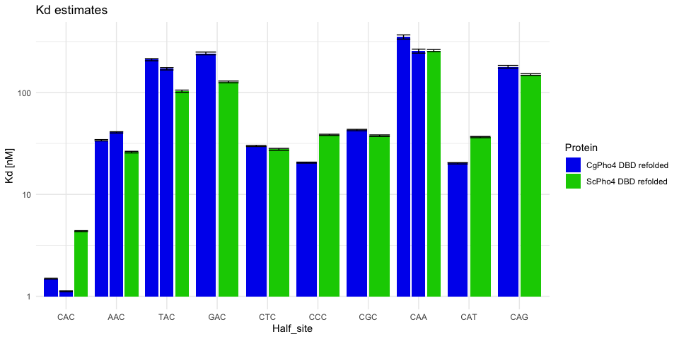